# Car Acceptability Classification

Exploratory Data Analysis & Machine Learning

Priya

May 01, 2026

# 1 Setup

## 1.1 Installing & Loading Packages

```r
packages <- c("nnet", "caret", "class", "gmodels", "C50",
              "klaR", "e1071", "kernlab", "caTools", "ggplot2", "infotheo",
              "dplyr", "reshape2")

new.packages <- packages[!(packages %in% installed.packages()[, "Package"])]
if (length(new.packages)) install.packages(new.packages)

invisible(lapply(packages, library, character.only = TRUE))
```

## 1.2 Importing the Dataset

```r
source_file <- "C:/Users/priya/OneDrive - Ulster University/University/CarSelection_Algorithm/car.csv"

df <- read.csv(source_file)
```

# 2 Exploratory Data Analysis & Data Preparation

## 2.1 Initial Inspection

```r
head(df)
```

|  | buying | maint | doors | persons | lug_boot | safety | acceptability |
| --- | --- | --- | --- | --- | --- | --- | --- |
| 1 | vhigh | low | 5more | 4 | small | low | unacc |
| 2 | high | vhigh | 3 | 2 | med | low | unacc |
| 3 | vhigh | high | 4 | 4 | big | med | unacc |
| 4 | high | vhigh | 5more | 4 | med | low | unacc |
| 5 | vhigh | high | 5more | 2 | med | high | unacc |
| 6 | med | vhigh | 4 | more | small | med | unacc |

```r
sum(is.na(df))  # Check for missing values
```

```
## [1] 0
```

```r
df <- data.frame(lapply(df, factor))  # Convert all columns to factors

summary(df)
```

```
##    buying      maint       doors     persons     lug_boot    safety
##  high :270   high :242   2    :243   2   :321   big  :341   high:330
##  low  :238   low  :248   3    :246   4   :343   med  :324   low :337
##  med  :257   med  :259   4    :259   more:336   small:335   med :333
##  vhigh:235   vhigh:251   5more:252
##  acceptability
##  acc  :231
##  good : 41
##  unacc:693
##  vgood: 35
```

```r
str(df)
```

```
## 'data.frame':    1000 obs. of  7 variables:
##  $ buying       : Factor w/ 4 levels "high","low","med",..: 4 1 4 1 4 3 3 2 3 3 ...
##  $ maint        : Factor w/ 4 levels "high","low","med",..: 2 4 1 4 1 4 3 4 2 2 ...
##  $ doors        : Factor w/ 4 levels "2","3","4","5more": 4 2 3 4 4 3 3 1 3 3 ...
##  $ persons      : Factor w/ 3 levels "2","4","more": 2 1 2 2 1 3 1 3 2 3 ...
##  $ lug_boot     : Factor w/ 3 levels "big","med","small": 3 2 1 2 2 3 1 1 3 1 ...
##  $ safety       : Factor w/ 3 levels "high","low","med": 2 2 3 2 1 3 3 1 3 3 ...
##  $ acceptability: Factor w/ 4 levels "acc","good","unacc",..: 3 3 3 3 3 3 3 1 1 2 ...
```

## 2.2 Counting with `table()`

`table()` lets us cross-tabulate categorical variables and spot patterns quickly.

```r
table(df$acceptability)
```

```
##
##   acc  good unacc vgood
##   231    41   693    35
```

```r
df$buying <- factor(df$buying, levels = c("vhigh", "high", "med", "low"))

table(df$buying, df$acceptability)
```

```
##
##         acc good unacc vgood
##   vhigh  40    0   195     0
##   high   72    0   198     0
##   med    68   14   162    13
##   low    51   27   138    22
```

> **Insight:** Low-price cars are more commonly rated as acceptable, suggesting price is a key driver of acceptability.

```r
table(df$safety, df$acceptability)
```

```
##
##        acc good unacc vgood
##   high 131   19   145    35
##   low    0    0   337     0
##   med  100   22   211     0
```

> **Insight:** 35 high-safety cars are rated `vgood`, while `low` and `med` safety cars have zero `vgood` ratings — safety is strongly tied to top ratings.

## 2.3 Visualising Variable Distributions

### 2.3.1 Acceptability

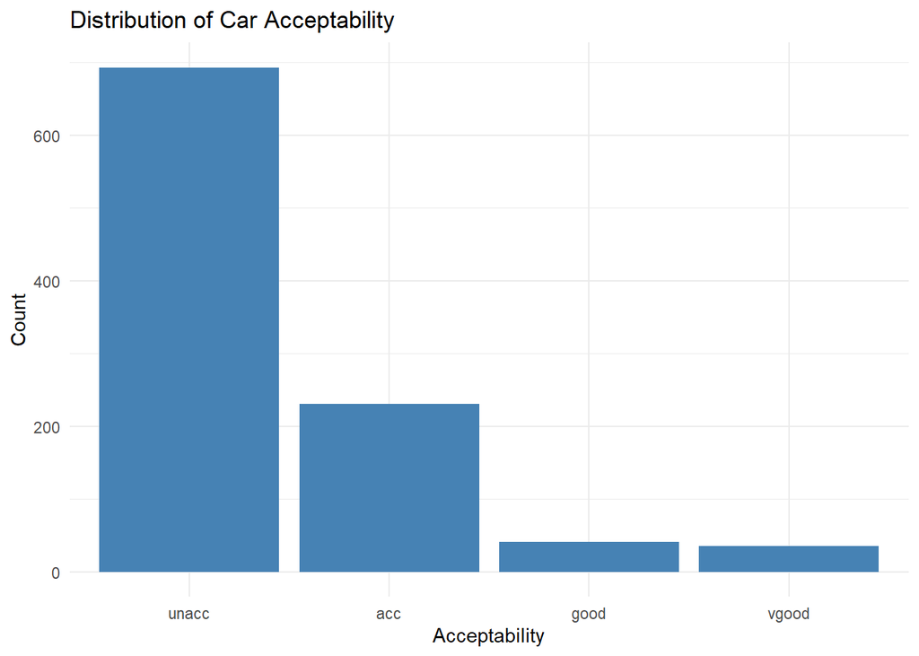

```r
df$acceptability <- factor(df$acceptability, levels = c("unacc", "acc", "good", "vgood"))

ggplot(df, aes(x = acceptability)) +
  geom_bar(fill = "steelblue") +
  labs(title = "Distribution of Car Acceptability",
       x = "Acceptability", y = "Count") +
  theme_minimal()
```

### 2.3.2 Acceptability vs. Buying Price

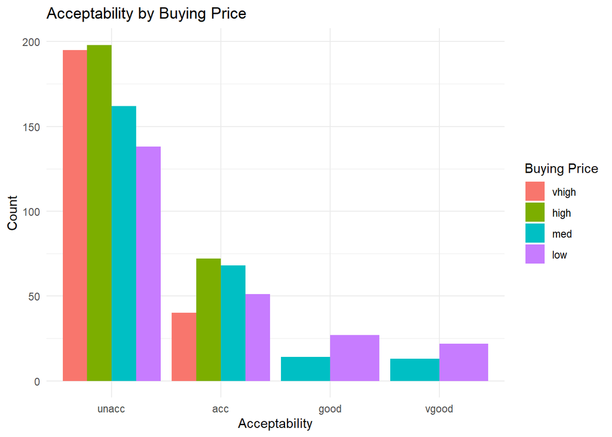

```r
ggplot(df, aes(x = acceptability, fill = buying)) +
  geom_bar(position = "dodge") +
  labs(title = "Acceptability by Buying Price",
       x = "Acceptability", y = "Count", fill = "Buying Price") +
  theme_minimal()
```

### 2.3.3 Acceptability vs. Safety

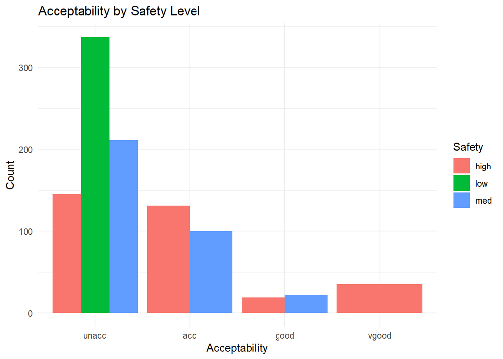

```r
ggplot(df, aes(x = acceptability, fill = safety)) +
  geom_bar(position = "dodge") +
  labs(title = "Acceptability by Safety Level",
       x = "Acceptability", y = "Count", fill = "Safety") +
  theme_minimal()
```

### 2.3.4 Acceptability vs. Persons

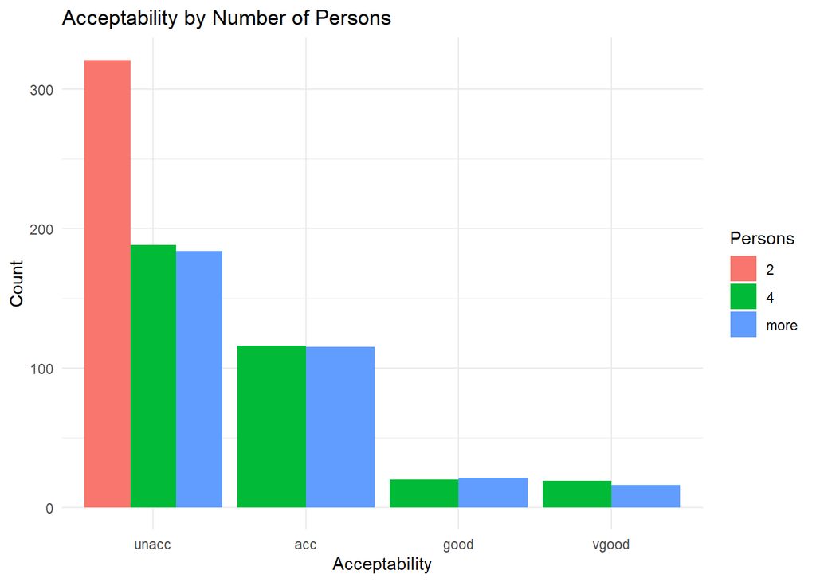

```r
ggplot(df, aes(x = acceptability, fill = persons)) +
  geom_bar(position = "dodge") +
  labs(title = "Acceptability by Number of Persons",
       x = "Acceptability", y = "Count", fill = "Persons") +
  theme_minimal()
```

### 2.3.5 Acceptability vs. Maintenance Cost

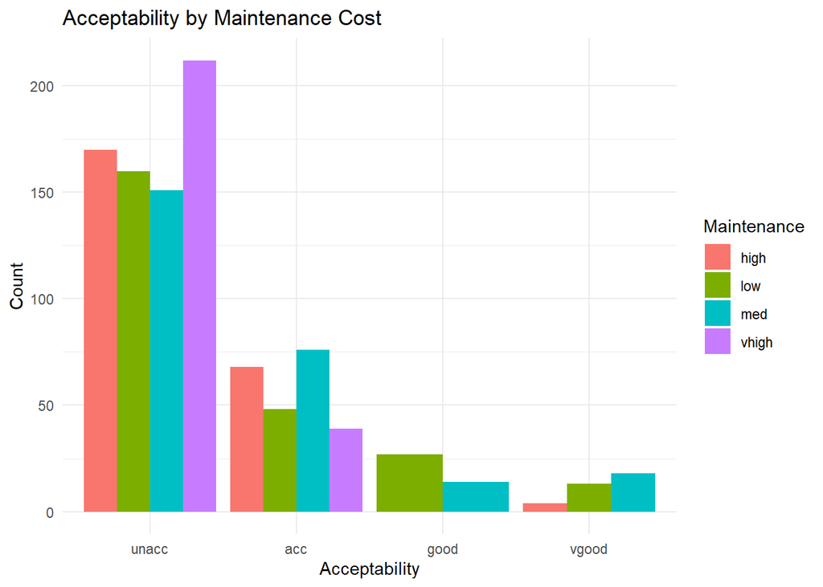

```r
ggplot(df, aes(x = acceptability, fill = maint)) +
  geom_bar(position = "dodge") +
  labs(title = "Acceptability by Maintenance Cost",
       x = "Acceptability", y = "Count", fill = "Maintenance") +
  theme_minimal()
```

# 3 Feature Relationships

## 3.1 Mutual Information Matrix

Mutual information (MI) measures the **strength** of a relationship between two variables — how much knowing one variable reduces uncertainty about the other.

> **Note:** The diagonal represents *entropy* (self-information) — how uncertain we are about a variable on its own.

```r
m <- mutinformation(df)
m
```

```
##                    buying       maint        doors     persons     lug_boot
## buying        1.384665780 0.002630072 0.0026151109 0.001730250 0.0012781665
## maint         0.002630072 1.385994865 0.0024207885 0.001993803 0.0006089410
## doors         0.002615111 0.002420789 1.3859951924 0.001125010 0.0015724629
## persons       0.001730250 0.001993803 0.0011250103 1.098231785 0.0014514422
## lug_boot      0.001278166 0.000608941 0.0015724629 0.001451442 1.0983887270
## safety        0.001601456 0.001308771 0.0003522822 0.001774065 0.0001767061
## acceptability 0.067509707 0.059097457 0.0039909755 0.149276771 0.0173662202
##                     safety acceptability
## buying        0.0016014559   0.067509707
## maint         0.0013087713   0.059097457
## doors         0.0003522822   0.003990976
## persons       0.0017740655   0.149276771
## lug_boot      0.0001767061   0.017366220
## safety        1.0985753063   0.191538120
## acceptability 0.1915381199   0.840929362
```

The values most relevant for modelling are the MI scores between each feature and the target (`acceptability`):

```r
m[7, -7]           # MI of acceptability vs. all other features
```

```
##      buying       maint       doors     persons    lug_boot      safety
## 0.067509707 0.059097457 0.003990976 0.149276771 0.017366220 0.191538120
```

```r
max(m[-7, 7])      # Feature with the highest MI with acceptability
```

```
## [1] 0.1915381
```

## 3.2 Chi-Squared Tests

The chi-squared test compares:

- **Observed counts** — what you see in the data
- **Expected counts** — what you’d see if the variables were completely unrelated

A **large χ²** means observed counts diverge strongly from expected → evidence of a relationship.

### 3.2.1 p-value Interpretation

| p-value | Interpretation |
| --- | --- |
| p > 0.05 | Could easily be random luck → no significant relationship |
| p ≤ 0.05 | Unlikely to be luck → statistically significant |
| p < 0.01 | Very unlikely → strong evidence of a relationship |
| p < 0.001 | Vanishingly unlikely → overwhelming evidence |

> **The Courtroom Analogy:** Defendants are presumed innocent (the *null hypothesis* H₀: no relationship). The prosecution must provide enough evidence (small p-value) to convict (reject H₀). Weak evidence (large p-value) → keep H₀.

### 3.2.2 Buying vs. Acceptability

```r
chisq.test(df$buying, df$acceptability)
```

```
##
##  Pearson's Chi-squared test
##
## data:  df$buying and df$acceptability
## X-squared = 113.82, df = 9, p-value < 2.2e-16
```

With **p < 2.2e-16**, we have overwhelming evidence that buying price and acceptability are related. The degrees of freedom `df = 9` comes from (4 levels − 1) × (4 levels − 1) = 9.

### 3.2.3 Buying vs. Maintenance

```r
chisq.test(df$buying, df$maint)
```

```
##
##  Pearson's Chi-squared test
##
## data:  df$buying and df$maint
## X-squared = 5.3384, df = 9, p-value = 0.8039
```

### 3.2.4 Safety vs. Acceptability

```r
chisq.test(df$safety, df$acceptability)
```

```
##
##  Pearson's Chi-squared test
##
## data:  df$safety and df$acceptability
## X-squared = 294.47, df = 6, p-value < 2.2e-16
```

> Both mutual information and chi-squared agree that **safety is strongly tied to acceptability**. When two independent methods reach the same conclusion, confidence in the finding increases — this is called *triangulation of evidence*.

# 4 Train / Test Split

Splitting the data before modelling is essential to get an honest estimate of how well a model will generalise to new, unseen data.

- **Overfitting** — model performs well on training data but poorly on new data
- **Underfitting** — model is too simple to even capture the training data well

```r
set.seed(7463)  # For reproducibility
split    <- sample.split(df$acceptability, SplitRatio = 0.8)
df_train <- subset(df, split == TRUE)
df_test  <- subset(df, split == FALSE)
```

## 4.1 Verifying the Split

Always sanity-check after splitting to confirm class proportions are preserved.

```r
cat("Training rows:", nrow(df_train), "\n")
```

```
## Training rows: 800
```

```r
cat("Test rows:    ", nrow(df_test),  "\n")
```

```
## Test rows:     200
```

```r
prop.table(table(df_train$acceptability))
```

```
##
##   unacc     acc    good   vgood
## 0.69250 0.23125 0.04125 0.03500
```

```r
prop.table(table(df_test$acceptability))
```

```
##
## unacc   acc  good vgood
## 0.695 0.230 0.040 0.035
```

The proportions should be very similar between train and test — confirming a stratified split.

# 5 Machine Learning Algorithms

The assignment covers five classification algorithms:

| Algorithm | Intuition |
| --- | --- |
| **Decision Tree (C5.0)** | Splits data using a series of yes/no questions |
| **Naive Bayes** | Estimates class probabilities from feature likelihoods |
| **Logistic Regression** | Models class probabilities using a linear boundary |
| **SVM** | Finds the maximum-margin hyperplane separating classes |
| **Neural Network** | Learns non-linear patterns through layered transformations |

## 5.1 The Universal ML Workflow

For every algorithm, the steps are identical:

```
1. TRAIN   → model = algorithm(train_features, train_target)
2. PREDICT → predictions = predict(model, test_data)
3. EVALUATE → confusionMatrix(predictions, true_labels)
```

## 5.2 Decision Tree (C5.0)

Decision trees build a series of if/else rules by asking the question that most reduces uncertainty at each step (measured by *information gain*).

**Why C5.0?** It is an evolution of the classic ID3 → C4.5 → C5.0 lineage, with better handling of categorical data and built-in pruning to reduce overfitting.

> **Analogy — 20 Questions:** Is safety low? → Yes → predict `unacc`. No → Is persons = 2? → Yes → predict `unacc`. No → ask another question…

### 5.2.1 Training

```r
dt_model <- C5.0(df_train[-7], df_train$acceptability)
```

### 5.2.2 Prediction

```r
dt_pred <- predict(dt_model, df_test)
```

### 5.2.3 Evaluation

A **confusion matrix** is a table that summarises how well a classification model performed by comparing its predictions against the actual known labels. Each **row** represents what the model *predicted*, and each **column** represents the *actual* class.

- The **diagonal cells** (top-left to bottom-right) are correct predictions.
- The **off-diagonal cells** are mistakes — where the model predicted one class but the true class was different.

For example, if the model predicted `acc` but the car was actually `good`, that count appears in the `acc` row, `good` column. The further values are from the diagonal, the worse the model is performing.

```r
confusionMatrix(dt_pred, df_test$acceptability)
```

```
## Confusion Matrix and Statistics
##
##           Reference
## Prediction unacc acc good vgood
##      unacc   137   3    0     0
##      acc       1  43    0     2
##      good      1   0    8     0
##      vgood     0   0    0     5
##
## Overall Statistics
##
##                Accuracy : 0.965
##                  95% CI : (0.9292, 0.9858)
##     No Information Rate : 0.695
##     P-Value [Acc > NIR] : < 2.2e-16
##
##                   Kappa : 0.9236
##
##  Mcnemar's Test P-Value : NA
##
## Statistics by Class:
##
##                      Class: unacc Class: acc Class: good Class: vgood
## Sensitivity                0.9856     0.9348      1.0000       0.7143
## Specificity                0.9508     0.9805      0.9948       1.0000
## Pos Pred Value             0.9786     0.9348      0.8889       1.0000
## Neg Pred Value             0.9667     0.9805      1.0000       0.9897
## Prevalence                 0.6950     0.2300      0.0400       0.0350
## Detection Rate             0.6850     0.2150      0.0400       0.0250
## Detection Prevalence       0.7000     0.2300      0.0450       0.0250
## Balanced Accuracy          0.9682     0.9577      0.9974       0.8571
```

**Key metrics to focus on:**

[output not shown]

## 5.3 Naive Bayes

Where decision trees ask *questions*, Naive Bayes calculates *probabilities*. It estimates the probability of each class given the observed features, then picks the class with the highest probability.

> **Analogy — Identifying Fruit:** You see something yellow, curved, and 15 cm long. Your brain combines past experience (“most yellow curved fruits are bananas”) to conclude — with high confidence — it’s a banana. Naive Bayes does exactly this using **Bayes’ Theorem**.

The “naive” part: it assumes all features are *independent* of each other given the class, which is rarely true in practice but works surprisingly well.

### 5.3.1 Training, Prediction & Evaluation

```r
set.seed(7463)
nb_model <- naiveBayes(df_train[, -7], df_train$acceptability)
nb_pred  <- predict(nb_model, df_test)
confusionMatrix(nb_pred, df_test$acceptability)
```

```
## Confusion Matrix and Statistics
##
##           Reference
## Prediction unacc acc good vgood
##      unacc   131  11    3     0
##      acc       7  32    4     3
##      good      1   3    1     0
##      vgood     0   0    0     4
##
## Overall Statistics
##
##                Accuracy : 0.84
##                  95% CI : (0.7817, 0.8879)
##     No Information Rate : 0.695
##     P-Value [Acc > NIR] : 1.829e-06
##
##                   Kappa : 0.6376
##
##  Mcnemar's Test P-Value : NA
##
## Statistics by Class:
##
##                      Class: unacc Class: acc Class: good Class: vgood
## Sensitivity                0.9424     0.6957      0.1250       0.5714
## Specificity                0.7705     0.9091      0.9792       1.0000
## Pos Pred Value             0.9034     0.6957      0.2000       1.0000
## Neg Pred Value             0.8545     0.9091      0.9641       0.9847
## Prevalence                 0.6950     0.2300      0.0400       0.0350
## Detection Rate             0.6550     0.1600      0.0050       0.0200
## Detection Prevalence       0.7250     0.2300      0.0250       0.0200
## Balanced Accuracy          0.8565     0.8024      0.5521       0.7857
```

## 5.4 Multinomial Logistic Regression

Multinomial logistic regression extends binary logistic regression to handle more than two classes. It fits one model per class against a reference class, then converts the log-odds into class probabilities using the **softmax** function.

> **Analogy — Opinion Polls:** Each feature casts a weighted vote for each class. The class that accumulates the most evidence (highest probability) wins.

The `multinom()` function from the `nnet` package is used here. `trace = FALSE` suppresses per-iteration output.

### 5.4.1 Training, Prediction & Evaluation

```r
set.seed(7463)
lg_model <- multinom(acceptability ~ ., data = df_train, trace = FALSE)
lg_pred  <- predict(lg_model, df_test)
confusionMatrix(lg_pred, df_test$acceptability)
```

```
## Confusion Matrix and Statistics
##
##           Reference
## Prediction unacc acc good vgood
##      unacc   132   3    0     0
##      acc       6  41    1     1
##      good      1   2    7     0
##      vgood     0   0    0     6
##
## Overall Statistics
##
##                Accuracy : 0.93
##                  95% CI : (0.8853, 0.9612)
##     No Information Rate : 0.695
##     P-Value [Acc > NIR] : 3.476e-16
##
##                   Kappa : 0.8515
##
##  Mcnemar's Test P-Value : NA
##
## Statistics by Class:
##
##                      Class: unacc Class: acc Class: good Class: vgood
## Sensitivity                0.9496     0.8913      0.8750       0.8571
## Specificity                0.9508     0.9481      0.9844       1.0000
## Pos Pred Value             0.9778     0.8367      0.7000       1.0000
## Neg Pred Value             0.8923     0.9669      0.9947       0.9948
## Prevalence                 0.6950     0.2300      0.0400       0.0350
## Detection Rate             0.6600     0.2050      0.0350       0.0300
## Detection Prevalence       0.6750     0.2450      0.0500       0.0300
## Balanced Accuracy          0.9502     0.9197      0.9297       0.9286
```

## 5.5 Support Vector Machine (SVM)

SVMs find the **maximum-margin hyperplane** that best separates classes in feature space. Using the **radial basis function (RBF) kernel**, SVMs can model non-linear decision boundaries by implicitly mapping data into a higher-dimensional space.

> **Analogy — Widest Road:** Imagine drawing a road between two groups of points. SVM finds the road that is as wide as possible — the points touching the road edges are the “support vectors”.

### 5.5.1 Training, Prediction & Evaluation

```r
set.seed(7463)
svm_model <- ksvm(acceptability ~ ., data = df_train, kernel = "rbfdot")
svm_pred  <- predict(svm_model, df_test)
confusionMatrix(svm_pred, df_test$acceptability)
```

```
## Confusion Matrix and Statistics
##
##           Reference
## Prediction unacc acc good vgood
##      unacc   131   0    0     0
##      acc       7  46    7     1
##      good      1   0    1     0
##      vgood     0   0    0     6
##
## Overall Statistics
##
##                Accuracy : 0.92
##                  95% CI : (0.8733, 0.9536)
##     No Information Rate : 0.695
##     P-Value [Acc > NIR] : 9.906e-15
##
##                   Kappa : 0.8309
##
##  Mcnemar's Test P-Value : NA
##
## Statistics by Class:
##
##                      Class: unacc Class: acc Class: good Class: vgood
## Sensitivity                0.9424     1.0000      0.1250       0.8571
## Specificity                1.0000     0.9026      0.9948       1.0000
## Pos Pred Value             1.0000     0.7541      0.5000       1.0000
## Neg Pred Value             0.8841     1.0000      0.9646       0.9948
## Prevalence                 0.6950     0.2300      0.0400       0.0350
## Detection Rate             0.6550     0.2300      0.0050       0.0300
## Detection Prevalence       0.6550     0.3050      0.0100       0.0300
## Balanced Accuracy          0.9712     0.9513      0.5599       0.9286
```

## 5.6 Neural Network

Neural networks learn patterns through layered transformations. An **input layer** receives the features, one or more **hidden layers** apply non-linear activations, and an **output layer** produces class probabilities via softmax.

> **Analogy — Brain Neurons:** Just as biological neurons fire when stimulated enough, artificial neurons activate when a weighted sum of inputs exceeds a threshold — cascading through layers to produce a prediction.

The `nnet()` function fits a single hidden-layer network. `size` controls the number of hidden units; `maxit` sets the maximum training iterations.

### 5.6.1 Training, Prediction & Evaluation

```r
set.seed(7463)
nn_model <- nnet(acceptability ~ ., data = df_train,
                 size = 5, maxit = 200, trace = FALSE)
nn_pred  <- predict(nn_model, df_test, type = "class")
confusionMatrix(
  factor(nn_pred, levels = levels(df_test$acceptability)),
  df_test$acceptability
)
```

```
## Confusion Matrix and Statistics
##
##           Reference
## Prediction unacc acc good vgood
##      unacc   135   0    0     0
##      acc       3  44    0     1
##      good      1   2    8     0
##      vgood     0   0    0     6
##
## Overall Statistics
##
##                Accuracy : 0.965
##                  95% CI : (0.9292, 0.9858)
##     No Information Rate : 0.695
##     P-Value [Acc > NIR] : < 2.2e-16
##
##                   Kappa : 0.9259
##
##  Mcnemar's Test P-Value : NA
##
## Statistics by Class:
##
##                      Class: unacc Class: acc Class: good Class: vgood
## Sensitivity                0.9712     0.9565      1.0000       0.8571
## Specificity                1.0000     0.9740      0.9844       1.0000
## Pos Pred Value             1.0000     0.9167      0.7273       1.0000
## Neg Pred Value             0.9385     0.9868      1.0000       0.9948
## Prevalence                 0.6950     0.2300      0.0400       0.0350
## Detection Rate             0.6750     0.2200      0.0400       0.0300
## Detection Prevalence       0.6750     0.2400      0.0550       0.0300
## Balanced Accuracy          0.9856     0.9653      0.9922       0.9286
```

# 6 Model Comparison

The table below summarises overall accuracy for each model on the held-out test set.

```r
results <- data.frame(
  Model = c("Decision Tree (C5.0)", "Naive Bayes",
            "Logistic Regression", "SVM", "Neural Network"),
  Accuracy = c(
    confusionMatrix(dt_pred,  df_test$acceptability)$overall["Accuracy"],
    confusionMatrix(nb_pred,  df_test$acceptability)$overall["Accuracy"],
    confusionMatrix(lg_pred,  df_test$acceptability)$overall["Accuracy"],
    confusionMatrix(svm_pred, df_test$acceptability)$overall["Accuracy"],
    confusionMatrix(
      factor(nn_pred, levels = levels(df_test$acceptability)),
      df_test$acceptability
    )$overall["Accuracy"]
  )
)

results$Accuracy <- round(results$Accuracy * 100, 2)
results[order(-results$Accuracy), ]
```

|  | Model | Accuracy |
| --- | --- | --- |
| 1 | Decision Tree (C5.0) | 96.5 |
| 5 | Neural Network | 96.5 |
| 3 | Logistic Regression | 93.0 |
| 4 | SVM | 92.0 |
| 2 | Naive Bayes | 84.0 |

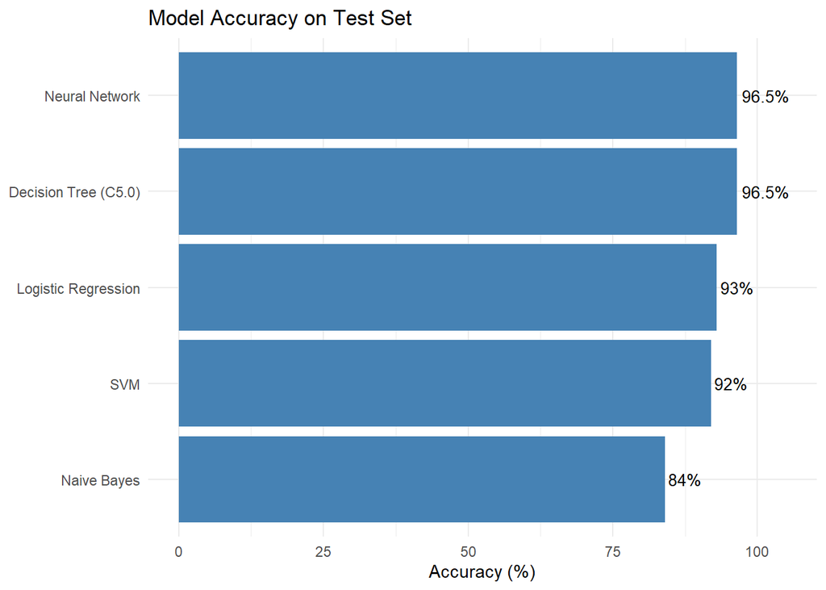

```r
ggplot(results, aes(y = reorder(Model, Accuracy), x = Accuracy)) +
  geom_col(fill = "steelblue") +
  geom_text(aes(label = paste0(Accuracy, "%")), hjust = -0.1, size = 3.5) +
  labs(title = "Model Accuracy on Test Set",
       y = NULL, x = "Accuracy (%)") +
  theme_minimal() +
  xlim(0, 105)
```